# Plotting examples for climate data

1. Introduction
2. Project preparation  
   2.1 Imports  
   2.2 Settings  
   2.3 Load and prepare datasets  
   2.4 Functions
3. Examples  
   3.1 Simple Plot  
   3.2 Seasonal Comparison
4. Links, References and more

# 1. Introduction

This notebook serves as an introduction to the world of visualization of climate data using python.

The data set discussed in this notebook contains historical daily surface temperature data from the model MPI-ESM1-2-LR with the configuration r1i1p1f1 gn. The time period covers the years 1970 to 2009. source: https://esgf-data.dkrz.de/search/cmip6-dkrz/ (File named: tas_day_MPI-ESM1-2-LR_historical_r1i1p1f1_gn_19700101-20091231.nc)

At the moment these are the common methods, for questions and comments please contact me via [this](https://b-schwertfeger.de/contact.php) form or mail.

(2021) Created by Benjamin Thomas Schwertfeger

benjamin.schwertfeger@awi.de  
Alfred Wegener Institute  
Helmholtz Centre for Polar and Marine Research  
Bussestraße 24  
D-27570 Bremerhaven  
Germany

# 2. Project preparation

## 2.1 Imports

```python
import sys, os, warnings
import numpy as np
import xarray as xr

#from tqdm import tqdm

import matplotlib as mpl, matplotlib.pyplot as plt, matplotlib.gridspec as gridspec
from mpl_toolkits.axes_grid1 import make_axes_locatable # for custom colorbar
from matplotlib.ticker import (MultipleLocator, AutoMinorLocator)

import cartopy, cartopy.crs as ccrs, cartopy.feature as cfeature, cartopy.mpl.ticker as cticker
from cartopy.feature import NaturalEarthFeature
from cartopy.util import add_cyclic_point

import seaborn as sns
```

## 2.2 Settings

```python
HOME = f"{os.environ.get('HOME')}/bschwertfeger"
PROJECT_ROOT_DIR = f"{HOME}/Examples"
DATA_ROOT_DIR = f"{PROJECT_ROOT_DIR}/data"

save_fig = False; img_path="images/"
sns.set_style("white"); warnings.filterwarnings("ignore");
```

```python
# add custom folder to python path to use own modules
#sys.path.append(os.path.abspath(os.path.join(HOME + "/myModules"))) # ~/yourname/myModules
#import YourModuleName as myMod
```

```python
mpl.rcParams["figure.titlesize"] = "large"
mpl.rcParams["figure.dpi"] = 96
mpl.rcParams["axes.titlesize"] = 18
mpl.rcParams["axes.labelsize"] = 16
mpl.rcParams["xtick.labelsize"] = 14
mpl.rcParams["ytick.labelsize"] = 14
mpl.rcParams["legend.fontsize"] = 12
```

## 2.3 Manipulate / prepare and load datasets

If you want to use only certain temporal or spatial sections, you can prepare your data with the command line tool [cdo](https://code.mpimet.mpg.de/projects/cdo/).

Get the description of the dataset:

```
cdo sinfo someFile.nc
```

Get the description of the variables in a dataset:

```
cdo pardes someFile.nc
```

selection of certain years:

```
cdo selyear,1980,1981,1982 inputfil.nc outputfile.nc
```

select the region europe:

```
cdo sellonlatbox,-45,60,25,65 someGlobalData.nc EUR_outputfile.nc
```

```
cdo yearmean -select,season=DJF -sellonlatbox,-45,60,25,65 -selvar,tas someGlobalData.nc EUR_DJF_yearmean_tas_1990-2000_outputfile.nc
```

```python
# load some data
data = xr.open_dataset(os.path.join(f"{DATA_ROOT_DIR}/tas_day_MPI-ESM1-2-LR_historical_r1i1p1f1_gn_19700101-20091231.nc")) # absolute path
# OR: xr.open_dataset("data/tas_day_MPI-ESM1-2-LR_historical_r1i1p1f1_gn_19700101-20091231.nc") # relative path
data
```

```
<xarray.Dataset>
Dimensions:    (bnds: 2, lat: 96, lon: 192, time: 14610)
Coordinates:
  * time       (time) datetime64[ns] 1970-01-01T12:00:00 ... 2009-12-31T12:00:00
  * lon        (lon) float64 0.0 1.875 3.75 5.625 ... 352.5 354.4 356.2 358.1
  * lat        (lat) float64 -88.57 -86.72 -84.86 -83.0 ... 84.86 86.72 88.57
    height     float64 2.0
Dimensions without coordinates: bnds
Data variables:
    time_bnds  (time, bnds) datetime64[ns] 1970-01-01 1970-01-02 ... 2010-01-01
    lon_bnds   (lon, bnds) float64 -0.9375 0.9375 0.9375 ... 357.2 357.2 359.1
    lat_bnds   (lat, bnds) float64 -89.5 -87.65 -87.65 ... 87.65 87.65 89.5
    tas        (time, lat, lon) float32 ...
Attributes: (12/49)
    CDI:                    Climate Data Interface version ?? (http://mpimet....
    history:                Mon Jul 12 14:20:16 2021: cdo mergetime tas_day_M...
    source:                 MPI-ESM1.2-LR (2017): \naerosol: none, prescribed...
    institution:            Max Planck Institute for Meteorology
    Conventions:            CF-1.7 CMIP-6.2
    activity_id:            CMIP
    ...                     ...
    variable_id:            tas
    variant_label:          r1i1p1f1
    license:                CMIP6 model data produced by MPI-M is licensed un...
    cmor_version:           3.5.0
    tracking_id:            hdl:21.14100/2c1e365b-a0db-422c-8ece-60104524f1b0
    CDO:                    Climate Data Operators version 1.9.3 (http://mpim...
```

```python
#drop useless variables
data = data.drop("lat_bnds").drop("lon_bnds").drop("time_bnds"); data
```

```
<xarray.Dataset>
Dimensions:  (lat: 96, lon: 192, time: 14610)
Coordinates:
  * time     (time) datetime64[ns] 1970-01-01T12:00:00 ... 2009-12-31T12:00:00
  * lon      (lon) float64 0.0 1.875 3.75 5.625 7.5 ... 352.5 354.4 356.2 358.1
  * lat      (lat) float64 -88.57 -86.72 -84.86 -83.0 ... 83.0 84.86 86.72 88.57
    height   float64 2.0
Data variables:
    tas      (time, lat, lon) float32 ...
Attributes: (12/49)
    CDI:                    Climate Data Interface version ?? (http://mpimet....
    history:                Mon Jul 12 14:20:16 2021: cdo mergetime tas_day_M...
    source:                 MPI-ESM1.2-LR (2017): \naerosol: none, prescribed...
    institution:            Max Planck Institute for Meteorology
    Conventions:            CF-1.7 CMIP-6.2
    activity_id:            CMIP
    ...                     ...
    variable_id:            tas
    variant_label:          r1i1p1f1
    license:                CMIP6 model data produced by MPI-M is licensed un...
    cmor_version:           3.5.0
    tracking_id:            hdl:21.14100/2c1e365b-a0db-422c-8ece-60104524f1b0
    CDO:                    Climate Data Operators version 1.9.3 (http://mpim...
```

```python
# output timemean temperatures per grid cell
data["tas"].mean("time")
```

```
<xarray.DataArray 'tas' (lat: 96, lon: 192)>
array([[224.7819 , 224.77597, 224.77899, ..., 224.81706, 224.80148,
        224.78725],
       [226.84172, 226.75858, 226.68903, ..., 227.2205 , 227.08058,
        226.95773],
       [227.877  , 227.7489 , 227.67088, ..., 228.52173, 228.25989,
        228.04424],
       ...,
       [258.66946, 258.79147, 258.90582, ..., 258.26794, 258.40527,
        258.54   ],
       [258.10352, 258.1314 , 258.15552, ..., 258.0109 , 258.0453 ,
        258.07504],
       [257.5139 , 257.5148 , 257.51764, ..., 257.5131 , 257.51266,
        257.51346]], dtype=float32)
Coordinates:
  * lon      (lon) float64 0.0 1.875 3.75 5.625 7.5 ... 352.5 354.4 356.2 358.1
  * lat      (lat) float64 -88.57 -86.72 -84.86 -83.0 ... 83.0 84.86 86.72 88.57
    height   float64 2.0
```

## 3. Examples

### 3.1 Simple Plot

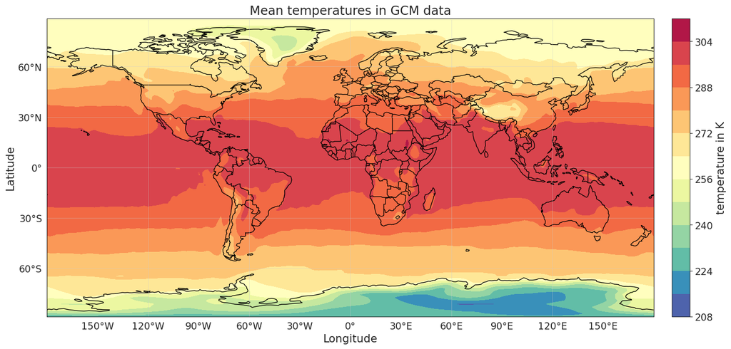

```python
cmap="Spectral_r"
#fsize_label, fsize_title, fsize_tick = 18, 22, 16

# ----- ----- ----- ----- ----- ----- ----- ----- ----- ----- ----- -----

fig = plt.figure(figsize=(20, 8), dpi=96)
ax = plt.subplot(projection=ccrs.PlateCarree())

# data["tas"].mean("time") -> mean over all timesteps
ds = data["tas"].mean("time")
lon = ds.coords["lon"]; lon_idx = ds.dims.index("lon")
wrap_data, wrap_lon = add_cyclic_point(ds, coord=lon, axis=lon_idx)
mappable = ax.contourf(
    wrap_lon, data.lat,
    wrap_data, transform=ccrs.PlateCarree(),
    cmap=cmap, levels=14, # levels defines how much colors should used (try 8 or 80)
    add_colorbar=False,
)

''' this is simple, but without adding a cyclic point it will display an uncolored line in the middle bc of index borders
mappable = data["tas"].mean("time").plot.contourf(
    ax=ax, cmap="Spectral_r",
    levels=33, add_colorbar=False
)
'''

ax.set_title("Mean temperatures in GCM data")

# ---- colorbar ----
divider = make_axes_locatable(ax)
cax = divider.append_axes("right", '3%', pad='3%', axes_class=mpl.pyplot.Axes)
cbar = ax.get_figure().colorbar(mappable, cax=cax, orientation="vertical")
cbar.set_label("temperature in K")

# -- -- -- -- -- -- -- --

# following is all optional
ax.set_xticks(np.arange(-180,181,30)[1:-1]); ax.set_yticks(np.arange(-90,91,30)[1:-1])

ax.set_ylabel("Latitude")
ax.set_xlabel("Longitude")

ax.set_yticklabels([x for x in ax.get_yticks()])
ax.set_xticklabels([x for x in ax.get_xticks()])
ax.yaxis.set_major_formatter(cticker.LatitudeFormatter())
ax.xaxis.set_major_formatter(cticker.LongitudeFormatter())

ax.add_feature(cartopy.feature.BORDERS)
ax.gridlines(alpha=0.6, linewidth=0.5)
ax.coastlines(); # if this does not work, try: ax.add_feature(cartopy.feature.GSHHSFeature(edgecolor='k'))

#plt.savefig(f"{title}.png");
```

## 3.2 Seasonal comparison

You can select the seasonal data via python and also with cdo on the command line. (cdo it is much faster and easier to reproduce)

```
#!/bin/bash

inputf=$1
seasons=(djf mam jja son)

set -e

trap 'last_command=$current_command; current_command=$BASH_COMMAND' DEBUG
trap 'echo "\"${last_command}\" command filed with exit code $?."' EXIT

inputf=$1

if [ ! -e $inputf ]
then
        echo "$inputf not found"
        exit
fi

for season in "${seasons[@]}"
do
    echo $season
    cdo yearmean -select,season=$season $inputf ${season}_${inputf}
done
`
```

Make it executable:

```
chmod u+x createSeasData.sh
`
```

Run with:

```
./createSeasData.sh inputfile.nc
`
```

> After that, there are 4 new files, each of which has the yearmean for its season in every year. (40 years each with one value in this example)

```python
# load seasonal yearmeans
djf_data_tas = xr.open_dataset(os.path.join(f"{DATA_ROOT_DIR}/djf_tas_day_MPI-ESM1-2-LR_historical_r1i1p1f1_gn_19700101-20091231.nc"))
mam_data_tas = xr.open_dataset(os.path.join(f"{DATA_ROOT_DIR}/mam_tas_day_MPI-ESM1-2-LR_historical_r1i1p1f1_gn_19700101-20091231.nc"))
jja_data_tas = xr.open_dataset(os.path.join(f"{DATA_ROOT_DIR}/jja_tas_day_MPI-ESM1-2-LR_historical_r1i1p1f1_gn_19700101-20091231.nc"))
son_data_tas = xr.open_dataset(os.path.join(f"{DATA_ROOT_DIR}/son_tas_day_MPI-ESM1-2-LR_historical_r1i1p1f1_gn_19700101-20091231.nc"))

seasons = { "DJF": djf_data_tas, "MAM": mam_data_tas, "JJA": jja_data_tas, "SON": son_data_tas }
```

```python
# get minimal and maximal values to make them comparable on the colobar
minimalValues = [seasons[x]["tas"].min().values.ravel()[0] for x in seasons]
maximalValues = [seasons[x]["tas"].max().values.ravel()[0] for x in seasons]

vmin = np.min(minimalValues)
vmax = np.max(maximalValues)
vmin, vmax
```

```
(201.1068115234375, 316.65765380859375)
```

```python
# define some variables
var = "tas"
start_year = str(np.array(seasons["DJF"]["time"].min().values.ravel()[0]))[:4]
end_year = str(np.array(seasons["DJF"]["time"].max().values.ravel()[0]))[:4]
start_year, end_year
```

```
('1970', '2009')
```

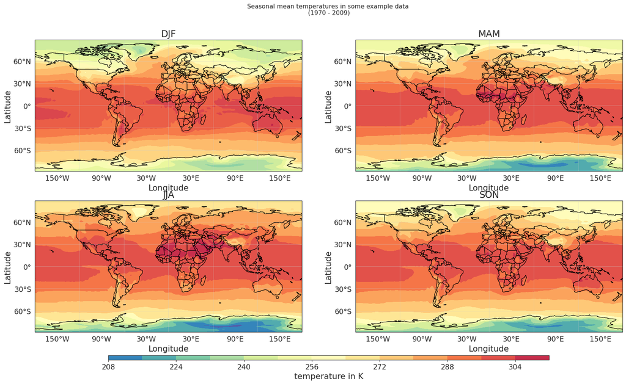

```python
# create figure
fig, axs = plt.subplots(nrows=2, ncols=2, figsize=(20,12), subplot_kw={ "projection": ccrs.PlateCarree() })
title=f"Seasonal mean temperatures in some example data \n({start_year} - {end_year})"
fig.suptitle(title)

row, col = 0, 0
for i, season in enumerate(seasons): # plot for every season
    ds = seasons[season][var].mean("time")
    lon = ds.coords["lon"]; lon_idx = ds.dims.index("lon")
    wrap_data, wrap_lon = add_cyclic_point(ds, coord=lon, axis=lon_idx)
    mappable = axs[row,col].contourf(
        wrap_lon, ds.lat,
        wrap_data, transform=ccrs.PlateCarree(),
        cmap=cmap, levels=14, vmin=vmin, vmax=vmax,
        add_colorbar=False,
    )
    axs[row,col].set_title(season)
    col += 1; row = row + 1 if col > 1 else row
    col = 0 if col > 1 == 1 else col

plt.tight_layout()
fig.subplots_adjust(bottom=0.23, top=0.9, left=0.1, right=0.9, wspace=0.2, hspace=0.2)

# add colorbar axis at the bottom of the graph
cbar_ax = fig.add_axes([0.2, 0.17, 0.6, 0.01])
# draw the colorbar
cbar=fig.colorbar(mappable, cax=cbar_ax,orientation="horizontal")
cbar.set_label("temperature in K")

# ticks, labels, coastlines (optional)
for row in range(2):
    for col in range(2):
        axs[row,col].set_xticks(np.arange(-180,181,30)[1:-1:2]); axs[row,col].set_yticks(np.arange(-90,91,30)[1:-1])

        axs[row,col].set_ylabel("Latitude")
        axs[row,col].set_xlabel("Longitude")

        axs[row,col].set_yticklabels([x for x in axs[row,col].get_yticks()])
        axs[row,col].set_xticklabels([x for x in axs[row,col].get_xticks()])
        axs[row,col].yaxis.set_major_formatter(cticker.LatitudeFormatter())
        axs[row,col].xaxis.set_major_formatter(cticker.LongitudeFormatter())

        axs[row,col].add_feature(cartopy.feature.BORDERS)
        axs[row,col].gridlines(alpha=0.6, linewidth=0.5)
        axs[row,col].coastlines(); # if this does not work, try: ax.add_feature(cartopy.feature.GSHHSFeature(edgecolor='k'))

#plt.savefig(f"{title}.png");
```

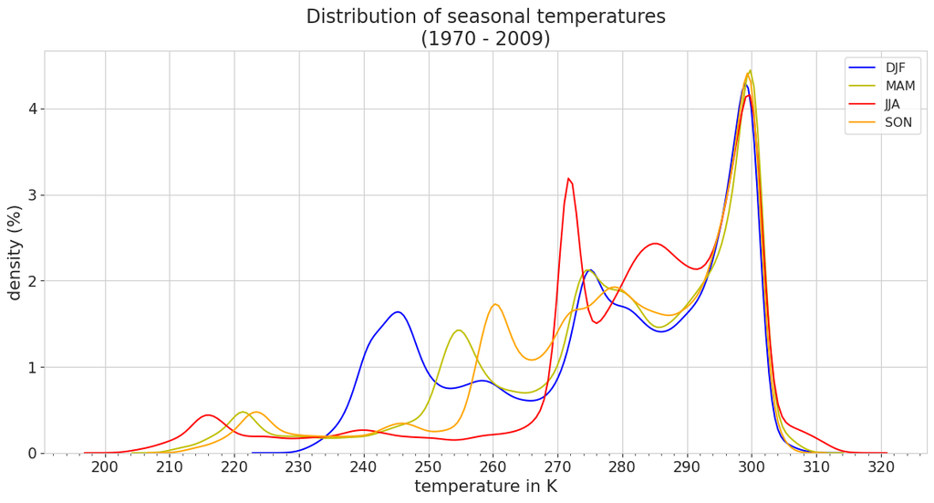

```python
hist, kde, rug = False, True, False # you try some other configurations
colors=["b", "y", "r", "orange"]

with sns.axes_style("whitegrid"):
    plt.figure(figsize=(15,7))
    for i, season in enumerate(seasons):
        sns.distplot(
            seasons[season]["tas"],
            label=season, color=colors[i],
            rug=rug, hist=hist, kde=kde
        )

    plt.gca().tick_params(which="both", bottom=True, left=True)
    plt.gca().xaxis.set_major_locator(MultipleLocator(10))
    plt.gca().xaxis.set_minor_locator(AutoMinorLocator())

    plt.gca().set_yticklabels(["{:.0f}".format(x*100) for x in plt.gca().get_yticks()])
    plt.gca().set_xticklabels([int(x) for x in plt.gca().get_xticks()])

    plt.legend()

    title = f"Distribution of seasonal temperatures\n({start_year} - {end_year})"
    plt.title(title)
    plt.ylabel("density (%)")
    plt.xlabel("temperature in K");

    #plt.savefig(f"{title}.png");
```

```python
# selecting a specific location (in this case: Bremerhaven, Germany)
lat_hb, lon_hb = 53.5396, 8.5809
seasons_hb = {
    "DJF": djf_data_tas.sel(lon=lon_hb, lat=lat_hb, method="nearest"),
    "MAM": mam_data_tas.sel(lon=lon_hb, lat=lat_hb, method="nearest"),
    "JJA": jja_data_tas.sel(lon=lon_hb, lat=lat_hb, method="nearest"),
    "SON": son_data_tas.sel(lon=lon_hb, lat=lat_hb, method="nearest")
}
years = [str(x)[:4] for x in [x.values.ravel()[0] for x in seasons_hb["DJF"]["time"]]]
```

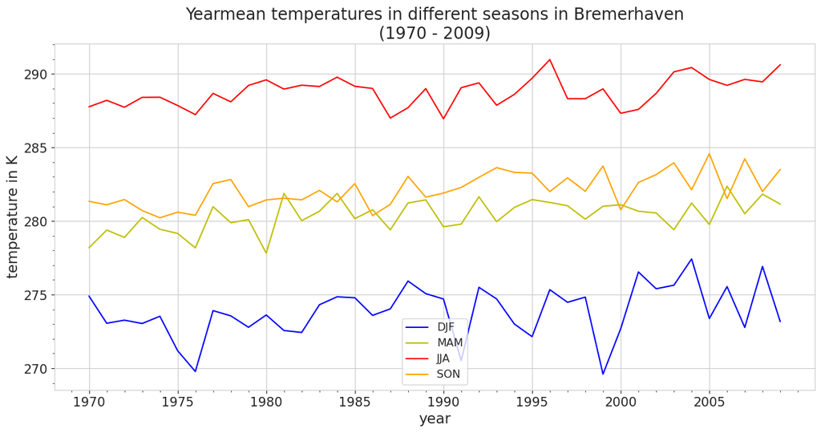

```python
with sns.axes_style("whitegrid"):
    plt.figure(figsize=(15,7), dpi=96)
    title = f"Yearmean temperatures in different seasons in Bremerhaven\n({start_year} - {end_year})"
    for i, season in enumerate(seasons_hb):
        plt.plot(seasons_hb[season]["tas"], label=season, color=colors[i])

    plt.legend()
    plt.title(title)

    plt.xlabel("year")
    plt.ylabel("temperature in K")

    plt.gca().set_xticks(np.arange(0,40)[::5])
    plt.gca().tick_params(which="both", bottom=True, left=True)
    plt.gca().xaxis.set_minor_locator(AutoMinorLocator())

    plt.gca().set_xticklabels(years[::5])
    plt.gca().set_yticklabels([int(x) for x in plt.gca().get_yticks()], fontsize=14)
    plt.gca().yaxis.set_minor_locator(AutoMinorLocator());
```

## Example how to select seasons in python (without cdo)

```python
# group by season
djf_timeIdx = data.groupby("time.season").groups["DJF"]
jja_timeIdx = data.groupby("time.season").groups["JJA"]

# get data by index
djf_data = [x for i, x in enumerate(data["tas"]) if i in djf_timeIdx]
jja_data = [x for i, x in enumerate(data["tas"]) if i in jja_timeIdx]
```

```python
# create xr.Dataarray from regular array / list
ds_djf = xr.DataArray(
    data = djf_data,
    dims = ["time", "lat", "lon"],
    coords = dict(
        time = [data["time"][i].values.ravel()[0] for i,x in enumerate(data["tas"]) if i in djf_timeIdx],
        lat = data["lat"], lon = data["lon"])
).transpose("lat", "lon", "time")
#ds_djf.to_netcdf("djf_tas_dataset.nc") # save as .nc file

ds_jja = xr.DataArray(
    data = jja_data,
    dims = ["time", "lat", "lon"],
    coords = dict(
        time = [data["time"][i].values.ravel()[0] for i,x in enumerate(data["tas"]) if i in jja_timeIdx],
        lat = data["lat"], lon = data["lon"])
).transpose("lat", "lon", "time")
```

```python
# calculate the timemean difference between winter and summer
ds_diff = ds_djf.mean("time") - ds_jja.mean("time")
```

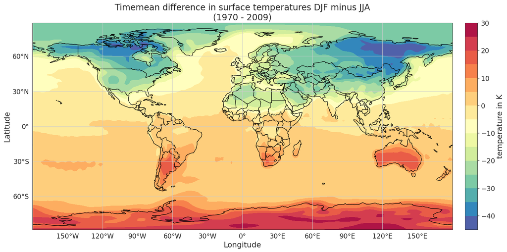

```python
fig = plt.figure(figsize=(20, 8), dpi=96)
ax = plt.subplot(projection=ccrs.PlateCarree())

ds = ds_diff
lon = ds.coords["lon"]; lon_idx = ds.dims.index("lon")
wrap_data, wrap_lon = add_cyclic_point(ds, coord=lon, axis=lon_idx)
mappable = ax.contourf(
    wrap_lon, ds_diff.lat,
    wrap_data, transform=ccrs.PlateCarree(),
    cmap=cmap, levels=14,
    add_colorbar=False,
)
title = f"Timemean difference in surface temperatures DJF minus JJA\n({start_year} - {end_year})"
ax.set_title(title)

# ---- colorbar ----
divider = make_axes_locatable(ax)
cax = divider.append_axes("right", '3%', pad='3%', axes_class=mpl.pyplot.Axes)
cbar = ax.get_figure().colorbar(mappable, cax=cax, orientation="vertical")
cbar.set_label("temperature in K")
# -- -- -- -- -- -- -- --

# following is all optional
ax.set_xticks(np.arange(-180,181,30)[1:-1]); ax.set_yticks(np.arange(-90,91,30)[1:-1])

ax.set_ylabel("Latitude")
ax.set_xlabel("Longitude")

ax.set_yticklabels([x for x in ax.get_yticks()])
ax.set_xticklabels([x for x in ax.get_xticks()])
ax.yaxis.set_major_formatter(cticker.LatitudeFormatter())
ax.xaxis.set_major_formatter(cticker.LongitudeFormatter())

ax.add_feature(cartopy.feature.BORDERS)
ax.gridlines(alpha=0.9, linewidth=0.8)
ax.coastlines(); # if this does not work, try: ax.add_feature(cartopy.feature.GSHHSFeature(edgecolor='k'))

#plt.savefig(f"{title}.png")
```

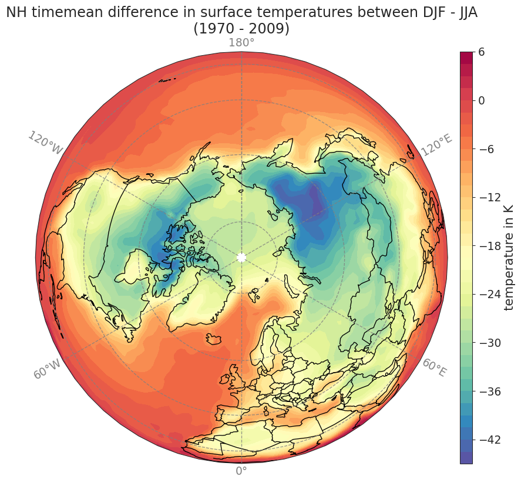

```python
fig = plt.figure(figsize=(10, 10), dpi=96)
ax = plt.subplot(projection=ccrs.Orthographic(0, 90))

ds = ds_diff.where(ds_diff["lat"] > 0)
lon = ds.coords["lon"]; lon_idx = ds.dims.index("lon")
wrap_data, wrap_lon = add_cyclic_point(ds, coord=lon, axis=lon_idx)
mappable = ax.contourf(
    wrap_lon, ds_diff.lat,
    wrap_data, transform=ccrs.PlateCarree(),
    cmap=cmap, levels=42,
    add_colorbar=False,
)
title = f"NH timemean difference in surface temperatures between DJF - JJA\n({start_year} - {end_year})"
ax.set_title(title)

# ---- colorbar ----
divider = make_axes_locatable(ax)
cax = divider.append_axes("right", "3%", pad="3%", axes_class=mpl.pyplot.Axes)
cbar = ax.get_figure().colorbar(mappable, cax=cax, orientation="vertical")
cbar.set_label("temperature in K")
# -- -- -- -- -- -- -- --

ax.add_feature(cartopy.feature.BORDERS)
ax.set_global()
gl = ax.gridlines(draw_labels=True, linewidth=1, alpha=0.8, linestyle="--", color='gray')
gl.xlabel_style = { "size": 14, "color": "gray" }
ax.coastlines(); # if this does not work, try: ax.add_feature(cartopy.feature.GSHHSFeature(edgecolor='k'))

#plt.savefig(f"{title}.png")
```

# 4. Links, references and more

Tools:

- Climate data operator to manipulate climate data: [cdo](https://code.mpimet.mpg.de/projects/cdo/)

Tutorials:

- Cartopy projections: https://scitools.org.uk/cartopy/docs/latest/crs/projections.html
- Multi panel plots using cartopy: https://kpegion.github.io/Pangeo-at-AOES/examples/multi-panel-cartopy.html
- Seaborn: https://seaborn.pydata.org/generated/seaborn.distplot.html
- Cyclic point: https://gist.github.com/darothen/c7560d8d19ffca90024c1f2df4927599

Data sources:

- DKRZ CMIP6: https://esgf-data.dkrz.de/search/cmip6-dkrz/
- DKRZ CORDEX: https://esgf-data.dkrz.de/search/cordex-dkrz/
- NOAA (observations): https://psl.noaa.gov/data/gridded/index.html